# ChIP AML PiPeline v2

```python
import os
import pandas as pd
import sys
sys.path.insert(0, '../..')
import itertools
from scipy import stats
import numpy as np

from JKBio.epigenetics import chipseq as chip
from JKBio.utils import helper
import igv
import SimpSOM as sps
from scipy import stats

import seaborn as sns
from matplotlib import cm
from matplotlib import pyplot as plt
from IPython.display import IFrame
import seaborn as sns
from bokeh.plotting import *
import igv
from collections import Counter

from scipy.special import factorial
from scipy.stats import fisher_exact

import numba
from numba import jit

from scipy.cluster.hierarchy import linkage, leaves_list
from sklearn.cluster import AgglomerativeClustering, DBSCAN, KMeans, OPTICS
from sklearn.mixture import GaussianMixture
from sklearn.manifold import MDS, TSNE
from sklearn.decomposition import PCA
from sklearn.preprocessing import scale
from IPython.display import IFrame

from pybedtools import BedTool
import pyBigWig

output_notebook()
%load_ext autoreload
%autoreload 2
```

```python
project="Cobinding_ChIP"
version="v3"
merging_version="remove_single"
window="150"
```

```python
%store -r merged
%store -r chrombed
%store -r mergedpeak
%store -r cols
%store -r annot
%store -r version
%store -r merging_version
%store -r window
```

## Doing Motif analysis

```python
! gsutil cp gs://genomics-public-data/resources/broad/hg38/v0/Homo_sapiens_assembly38.fasta ../../data/ref
! gsutil cp gs://genomics-public-data/resources/broad/hg38/v0/Homo_sapiens_assembly38.dict ../../data/ref
```

```
Copying gs://genomics-public-data/resources/broad/hg38/v0/Homo_sapiens_assembly38.dict...
/ [1 files][568.1 KiB/568.1 KiB]
Operation completed over 1 objects/568.1 KiB.
```

```python
gatk='java -jar ~/gatk-4.1.9.0/gatk-package-4.1.9.0-local.jar'
```

```python
#snps
! gsutil cp gs://fc-secure-bd7b8bc9-f665-4269-997e-5a402088a369/f6f6b60e-cce8-45ef-aa4f-ef2a9c636ebe/Cram2FilteredVcf/4297eb57-caaa-4c7f-8d36-446174db724f/call-FilterVariantTranches/CDS-XBgVc6_cnn_filtered.vcf.gz ../temp/input_snp.vcf.gz
! gsutil cp gs://fc-secure-bd7b8bc9-f665-4269-997e-5a402088a369/f6f6b60e-cce8-45ef-aa4f-ef2a9c636ebe/Cram2FilteredVcf/4297eb57-caaa-4c7f-8d36-446174db724f/call-FilterVariantTranches/CDS-XBgVc6_cnn_filtered.vcf.gz.tbi ../temp/input_snp.vcf.gz.tbi
```

```
Copying gs://fc-secure-bd7b8bc9-f665-4269-997e-5a402088a369/f6f6b60e-cce8-45ef-aa4f-ef2a9c636ebe/Cram2FilteredVcf/4297eb57-caaa-4c7f-8d36-446174db724f/call-FilterVariantTranches/CDS-XBgVc6_cnn_filtered.vcf.gz...
- [1 files][250.3 MiB/250.3 MiB]
Operation completed over 1 objects/250.3 MiB.
Copying gs://fc-secure-bd7b8bc9-f665-4269-997e-5a402088a369/f6f6b60e-cce8-45ef-aa4f-ef2a9c636ebe/Cram2FilteredVcf/4297eb57-caaa-4c7f-8d36-446174db724f/call-FilterVariantTranches/CDS-XBgVc6_cnn_filtered.vcf.gz.tbi...
/ [1 files][  2.2 MiB/  2.2 MiB]
Operation completed over 1 objects/2.2 MiB.
```

```python
## computing motif across the open region of the genome of MV411 from ATACseq with MEME.mast
! mkdir ../../data/$project/MEME_$version/
! cp ../../data/$project/ATAC_MV411.mRp.clN_peaks.broadPeak ../../data/$project/ATAC_MV411.mRp.clN_peaks.bed && $gatk FastaAlternateReferenceMaker -R ../../data/ref/Homo_sapiens_assembly38.fasta -O ../temp/middle.fasta -L ../../data/$project/ATAC_MV411.mRp.clN_peaks.bed -V ../temp/input_snp.vcf.gz && fold ../temp/middle.fasta -w 500 > ../../data/$project/MEME_$version/ATAC.fasta

cmd = "export PATH=$HOME/meme/bin:$HOME/meme/libexec/meme-5.1.1:$PATH && fimo --oc ../../data/"+project+"/MEME_"+version+"/ATAC/ ../../motif_databases/HUMAN/HOCOMOCOv11_full_HUMAN_mono_meme_format.meme ../../data/"+project+"/MEME_"+version+"/ATAC.fasta"
! $cmd

! gff2bed < ../../data/$project/MEME_$version/ATAC/fimo.gff > ../../data/$project/MEME_$version/ATAC/fimo.gff.bed
```

[output not shown]

[output cut: 4747 more lines]

[output not shown]

```python
merged_motif = pd.read_csv('../../data/MEME/merged/fimo.gff.bed', sep='\t',skiprows=0,index_col=None, names=['pos', 'relstart', 'relend', "name", "strength","strand",'fimo','nucleotide_motif',".","data"])

merged_motif['tf'] = [i.split('_HUMAN')[0] for i in merged_motif.name]
merged_motif.relstart = merged_motif.relstart.astype(int)
merged_motif['start'] = [i.split(':')[1].split('-')[0] for i in merged_motif.pos]
merged_motif.start = merged_motif.start.astype(int)
merged_motif.relend = merged_motif.relend.astype(int)
merged_motif.start = merged_motif.start+merged_motif.relstart
merged_motif['end'] = merged_motif.start+merged_motif.relend
merged_motif['chrom'] = [i.split(':')[0][3:] for i in merged_motif.pos]
```

[output not shown]

```python
rn={'HOXA9':'HXA9',
 'SREBF1':'SRBP1',
 'STAT5B':'STA5B',
 'ZEB2':"ZEB1",
 'ZNF281':'ZN281'}
proteins = []
for i in merged.columns[cols:]:
    for k,v in rn.items():
        i = i.replace(k,v)
    proteins.append(i)
set(proteins) - set(merged_motif.tf)
```

```
{'AFF4',
 'BRD4',
 'CDK13',
 'CDK9',
 'FLAG_GFI1',
 'FLAG_IRF2BP2',
 'FLAG_MEF2C',
 'FLAG_MEF2D',
 'FLAG_SPI1',
 'H3K27ac',
 'H3K27me3',
 'H3K36me2',
 'H3K36me3',
 'H3K4me1',
 'H3K4me3',
 'H3K79me2',
 'H3K9ac',
 'LDB1',
 'LMO2',
 'MED1',
 'MLL_KTM2A',
 'MYBL2',
 'PLAGL2',
 'POLII',
 'PSER2',
 'SMC1',
 'WDR5',
 'ZMYND8',
 'activation',
 'repression',
 'super_enhancer'}
```

```python
merged_motif = merged_motif[merged_motif.tf.isin(proteins)]
merged_motif['pval'] = [float(i.split('pvalue=')[1].split(';')[0]) for i in merged_motif.data]
merged_motif['seq'] = [i.split('sequence=')[1].split(';')[0] for i in merged_motif.data]
merged_motif = merged_motif[['chrom', 'start', 'end', "strength", 'pval','strand', 'tf','seq']].sort_values(by=['chrom','start','strength']).reset_index(drop = True)
merged_motif = merged_motif.rename(columns={'chr':'chrom'})
merged_motif.chrom = "chr"+merged_motif.chrom
merged_motif.chrom = merged_motif.chrom.astype(str)
```

[output not shown]

```python
a = {}
for k,v in rn.items():
    a[v] = k
rn = a
merged_motif['tf'] = merged_motif['tf'].replace(rn)
```

```python
merged_motif = merged_motif.rename(columns={'strength':"foldchange"})
```

```python
merged_motif
```

|  | chrom | start | end | foldchange | pval | strand | tf | seq |
| --- | --- | --- | --- | --- | --- | --- | --- | --- |
| 0 | chr1 | 10282 | 10707 | 40.5 | 0.000090 | - | RUNX2 | GGGTTGGGGTTAGG |
| 1 | chr1 | 10288 | 10719 | 41.6 | 0.000069 | - | RUNX2 | GGGTTGGGGTTGGG |
| 2 | chr1 | 10294 | 10731 | 41.6 | 0.000069 | - | RUNX2 | GGGTTGGGGTTGGG |
| 3 | chr1 | 10300 | 10743 | 41.6 | 0.000069 | - | RUNX2 | GGGTTGGGGTTGGG |
| 4 | chr1 | 10306 | 10755 | 41.6 | 0.000069 | - | RUNX2 | GGGTTGGGGTTGGG |
| ... | ... | ... | ... | ... | ... | ... | ... | ... |
| 2241485 | chrY | 56876566 | 56876635 | 56.1 | 0.000002 | - | SPI1 | GGATAGCGGAAGTGAAA |
| 2241486 | chrY | 56876568 | 56876635 | 52.9 | 0.000005 | - | ELF2 | ATAGCGGAAGTGA |
| 2241487 | chrY | 56876668 | 56876833 | 46.0 | 0.000025 | - | MYC | GCCATGTGTTT |
| 2241488 | chrY | 56878627 | 56878678 | 45.3 | 0.000030 | + | GATA2 | AAAGATAAGAG |
| 2241489 | chrY | 56878748 | 56878926 | 43.9 | 0.000041 | - | RARA | AGGTGATCAAATGGTAA |

2241490 rows × 8 columns

```python
merged_motif.to_csv('../results/'+project+'/large/'+version+'_merged_motif.bed.gz', sep='\t')
```

```python
merged_motif = pd.read_csv('../results/'+project+'/large/'+version+'_merged_motif.bed.gz', sep='\t')
```

[output not shown]

## what motifs map to their right binding event

```python
set(merged.columns)
```

```
{'-log10pvalue',
 '-log10qvalue',
 'AFF4',
 'ATAC',
 'BRD4',
 'CDK13',
 'CDK9',
 'CEBPA',
 'CEBPA_mot',
 'CEBPB',
 'CEBPB_mot',
 'CTCF',
 'CTCF_mot',
 'E2F3',
 'E2F3_mot',
 'ELF2',
 'ELF2_mot',
 'ETV6',
 'ETV6_mot',
 'FLAG_GFI1',
 'FLAG_IRF2BP2',
 'FLAG_MEF2C',
 'FLAG_MEF2D',
 'FLAG_SPI1',
 'FLI1',
 'FLI1_mot',
 'FOSL2',
 'FOSL2_mot',
 'FOXP1',
 'FOXP1_mot',
 'GATA2',
 'GATA2_mot',
 'H3K27ac',
 'H3K27me3',
 'H3K36me2',
 'H3K36me3',
 'H3K4me1',
 'H3K4me3',
 'H3K79me2',
 'H3K9ac',
```

[output cut: 46 more lines]

```
 'ZEB2_mot',
 'ZMYND8',
 'ZNF281',
 'ZNF281_mot',
 'activation',
 'chrom',
 'end',
 'foldchange',
 'peak_number',
 'promoters',
 'regular_enhancer',
 'relative_summit_pos',
 'repression',
 'start',
 'super_enhancer'}
```

```python
for val in set(merged_motif.tf):
    merged[val+'_mot'] = chip.putInBed(merged[merged.columns[:cols]], merged_motif[merged_motif.tf==val], window=100)
merged = merged.replace(np.nan,0)
```

```
37051 were merged into conscensus
28460 were merged into conscensus
20639 were merged into conscensus
27714 were merged into conscensus
30756 were merged into conscensus
23331 were merged into conscensus
33019 were merged into conscensus
16499 were merged into conscensus
56274 were merged into conscensus
24886 were merged into conscensus
66657 were merged into conscensus
18652 were merged into conscensus
21410 were merged into conscensus
23950 were merged into conscensus
27531 were merged into conscensus
```

[output cut: 17 more lines]

```python
merged[merged["MAX_mot"]!=0]["STAT5B"].astype(bool).sum() / merged["MAX_mot"].astype(bool).sum()
```

```
0.3993817949264549
```

### computing frequency binding of a motif with its TF.

barplot of the percentage of peaks that overlap with Motifs found for the same TF. peaks are found with MACS2. We are only looking at Motifs on the regions defined by the cobinding matrix: (regions with at least 2 CRC TF cobinding).

```python
a = []
b = []
for val in set(merged.columns[8:]):
    if '_mot' in val:
        b.append(val[:-4])
        a.append(merged[merged[val]!=0][val[:-4]].astype(bool).sum() / merged[val[:-4]].astype(bool).sum())
```

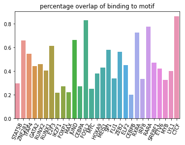

```python
sns.barplot(data=pd.DataFrame(data = a, index=b, columns=['counts']).T)
plt.xticks(rotation=65)
plt.title("percentage overlap of binding to motif")
plt.savefig("../results/"+project+'/plots/'+version+'_'+merging_version+'_'+window+"percentage_overlap_binding2motif.pdf")
```

```python
np.mean(a)
```

```
0.46220848463486913
```

```python
mergedmot = merged
%store mergedmot
```

```
Stored 'mergedmot' (DataFrame)
```

```python
%store -r mergedmot
```

## Unbound Open region Motifs:

What are the motifs of our CRC members in ATACseq but not in our matrix

```python
overlap = [25208, 54903, 24089, 65091, 33666, 42825, 32539, 16402, 20276, 14741, 21896, 100287, 18913, 24846, 25447, 89784, 43004, 35733, 33211, 27676, 45552, 55072, 42383, 32933, 23000, 30475, 31295, 27557, 75131]
```

```python
merged_motif['tf'] = merged_motif.tf.replace({"SRBP1":"SREBF1","HXA9":"HOXA9"})
```

```python
a = []
b = []
for i, val in enumerate([i[:-4] for i in mergedmot.columns[72:]]):
    b.append(val)
    a.append(overlap[i] / (merged_motif.tf==val).sum())
```

[output not shown]

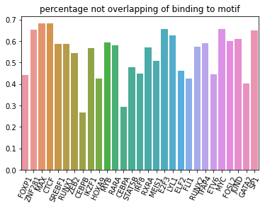

```python
sns.barplot(data=pd.DataFrame(data = a, index=b, columns=['counts']).T)
plt.xticks(rotation=65)
plt.title("percentage not overlapping of binding to motif")
plt.savefig("../results/"+project+'/plots/'+version+'_'+merging_version+'_'+window+"percentage_nonoverlap_binding2motif.pdf")
```

```python
mergedmot.columns[8:37]
```

```
Index(['CEBPA', 'HOXA9', 'PLAGL2', 'MEIS1', 'ETV6', 'HEX', 'FLAG_GFI1',
       'RUNX1', 'FOSL2', 'FLI1', 'GATA2', 'SP1', 'E2F3', 'ZNF281', 'SREBF1',
       'LMO2', 'STAT5B', 'ZMYND8', 'FLAG_MEF2C', 'LYL1', 'MYC', 'TFAP4',
       'RUNX2', 'MAX', 'IRF8', 'MYB', 'ZEB2', 'RXRA', 'FLAG_MEF2D'],
      dtype='object')
```

## regulatory code:

For each TF with known motifs, we look at the set of possible sets of cobinding CRC TF. for each set we compute its enrichment. we then display the most enriched sets

Issue: Due to the exponential complexity of computing each possible pvalues, we do not, the test is thus not BH corrected when it is on a set of $\sum_{k = 2..10} {29 \choose k}$ possible realizations: 36,519,526 and it is not chosen randomly

```python
from scipy.special import comb
suma=0
for i in range(2,11):
    suma += comb(29,i)
int(suma)
```

```
36519526
```

```python
#@jit(parallel=True)
def compfish(e, proba, size1, size2):
    folds = {}
    pvals = {}
    i=0
    for k, v in e.items():
        if len(k)<9 and v>100:
            a = np.prod(proba[list(k)])#*factorial(len(k))
            if (a / size1) * 1.2 < v / size2:
                a = int(a*size2)
                i+=1
                fold, p = fisher_exact([[size1-a,a],[size2-v,v]])
                folds[fold] = k
                pvals[k] = p
    print(i)
    return folds, pvals
```

```python
## what enrichment do we have in each group? what enrichment do we have for each ChipSeq?
res = {val: {} for i, val in enumerate([i[:-4] for i in mergedmot.columns[72:]])}
proba = mergedmot[mergedmot.columns[8:37]].astype(bool).sum()/len(mergedmot)
for i, val in enumerate([i[:-4] for i in mergedmot.columns[72:]]):
    a,b = np.where(mergedmot[(mergedmot[val]!=0)][mergedmot.columns[8:37]]!=0) #72
    e = []
    u = []
    preva=a[0]
    print('_________________')
    print(val)
    for i, v in enumerate(a):
        n = mergedmot.columns[8+b[i]]
        if n == val or n=="CEBPA":
            continue
        # we are still on the same row
        if v == preva:
            u.append(n)
            e.append(tuple(u))
        # we moved
        else:
            e.append(tuple(u))
            u = [n]
        preva = v
    e = Counter(e)
    s = len(set(a))
    d,f = compfish(dict(e), proba, len(mergedmot), s)
    #    v = (v/s)*100
    #    if v >5:
    #        d[v] = k
    a = list(d.keys())
    a.sort()
    for v in a[::-1]:
    #    print("%.2f%% for: %s" % (v, str(d[v])))
        if v>9:
            print("%.2f,%.2f for: %s" % (v, f[d[v]], str(d[v]), ))
        res[val][d[v]] = (v, f[d[v]])
```

```
_________________
FOXP1
302
inf,0.00 for: ('PLAGL2', 'MEIS1', 'ETV6', 'RUNX1', 'FOSL2', 'FLI1', 'SP1')
3303.09,0.00 for: ('PLAGL2', 'MEIS1', 'FLAG_GFI1', 'RUNX1', 'FLI1', 'SP1', 'E2F3')
2603.85,0.00 for: ('PLAGL2', 'MEIS1', 'RUNX1', 'FLI1', 'SP1', 'E2F3', 'ZNF281')
1207.63,0.00 for: ('PLAGL2', 'MEIS1', 'ETV6', 'RUNX1', 'FLI1', 'SP1')
1113.40,0.00 for: ('PLAGL2', 'MEIS1', 'ETV6', 'FLAG_GFI1', 'RUNX1', 'FLI1')
992.06,0.00 for: ('PLAGL2', 'MEIS1', 'RUNX1', 'FLI1', 'SP1', 'E2F3', 'LMO2')
703.16,0.00 for: ('MEIS1', 'RUNX1', 'FLI1', 'SP1', 'E2F3', 'ZNF281', 'LMO2')
485.20,0.00 for: ('PLAGL2', 'MEIS1', 'ETV6', 'FLAG_GFI1', 'RUNX1')
483.67,0.00 for: ('PLAGL2', 'MEIS1', 'ETV6', 'RUNX1', 'FLI1', 'GATA2')
471.34,0.00 for: ('PLAGL2', 'MEIS1', 'RUNX1', 'FLI1', 'SP1', 'E2F3')
457.03,0.00 for: ('PLAGL2', 'MEIS1', 'ETV6', 'RUNX1', 'FOSL2')
442.24,0.00 for: ('PLAGL2', 'ETV6', 'RUNX1', 'FLI1', 'SP1', 'E2F3')
427.44,0.00 for: ('PLAGL2', 'RUNX1', 'FLI1', 'SP1', 'E2F3', 'ZNF281')
418.57,0.00 for: ('PLAGL2', 'MEIS1', 'FLAG_GFI1', 'RUNX1', 'FLI1', 'GATA2', 'SP1')
342.67,0.00 for: ('MEIS1', 'FLAG_GFI1', 'RUNX1', 'FLI1', 'SP1', 'E2F3', 'ZNF281')
341.72,0.00 for: ('MEIS1', 'FLAG_GFI1', 'RUNX1', 'FLI1', 'SP1', 'E2F3', 'LMO2')
335.81,0.00 for: ('PLAGL2', 'ETV6', 'FLAG_GFI1', 'RUNX1', 'FLI1', 'SP1')
316.75,0.00 for: ('PLAGL2', 'FLAG_GFI1', 'RUNX1', 'FLI1', 'SP1', 'E2F3')
288.42,0.00 for: ('PLAGL2', 'MEIS1', 'FLAG_GFI1', 'RUNX1', 'FLI1', 'SP1')
244.80,0.00 for: ('MEIS1', 'RUNX1', 'FLI1', 'SP1', 'E2F3', 'LMO2', 'STAT5B')
238.87,0.00 for: ('PLAGL2', 'MEIS1', 'FLAG_GFI1', 'RUNX1', 'FOSL2', 'FLI1')
237.51,0.00 for: ('PLAGL2', 'MEIS1', 'ETV6', 'RUNX1', 'FLI1')
195.78,0.00 for: ('PLAGL2', 'MEIS1', 'ETV6', 'FLAG_GFI1')
187.11,0.00 for: ('PLAGL2', 'MEIS1', 'RUNX1', 'FOSL2', 'FLI1', 'SP1')
178.24,0.00 for: ('PLAGL2', 'RUNX1', 'FLI1', 'SP1', 'E2F3', 'LMO2')
153.14,0.00 for: ('PLAGL2', 'MEIS1', 'RUNX1', 'FLI1', 'SP1', 'LMO2', 'STAT5B')
141.98,0.00 for: ('MEIS1', 'ETV6', 'FLAG_GFI1', 'RUNX1', 'FLI1', 'SP1')
121.66,0.00 for: ('MEIS1', 'ETV6', 'RUNX1', 'FLI1', 'SP1', 'E2F3')
114.89,0.00 for: ('MEIS1', 'RUNX1', 'FLI1', 'SP1', 'LMO2', 'STAT5B', 'ZMYND8')
109.10,0.00 for: ('PLAGL2', 'MEIS1', 'ETV6', 'RUNX1')
102.68,0.00 for: ('MEIS1', 'RUNX1', 'FLI1', 'SP1', 'E2F3', 'ZNF281')
100.12,0.00 for: ('MEIS1', 'ETV6', 'FLAG_GFI1', 'RUNX1', 'FLI1', 'GATA2')
99.69,0.00 for: ('PLAGL2', 'MEIS1', 'FLAG_GFI1', 'RUNX1', 'FOSL2')
94.93,0.00 for: ('PLAGL2', 'MEIS1', 'FLAG_GFI1', 'RUNX1', 'FLI1', 'GATA2')
92.08,0.00 for: ('MEIS1', 'FLAG_GFI1', 'RUNX1', 'FLI1', 'SP1', 'E2F3')
87.81,0.00 for: ('PLAGL2', 'MEIS1', 'ETV6')
80.12,0.00 for: ('PLAGL2', 'MEIS1', 'RUNX1', 'FLI1', 'GATA2', 'SP1')
```

[output cut: 1796 more lines]

```
14.80,0.00 for: ('PLAGL2', 'ETV6')
14.30,0.00 for: ('MEIS1', 'RUNX1', 'FLI1', 'STAT5B', 'ZMYND8', 'MYC')
13.94,0.00 for: ('MEIS1', 'RUNX1', 'FLI1', 'LMO2', 'STAT5B')
13.02,0.00 for: ('MEIS1', 'FLAG_GFI1', 'RUNX1', 'FLI1', 'STAT5B')
12.95,0.00 for: ('MEIS1', 'ETV6', 'RUNX1')
12.16,0.00 for: ('HOXA9', 'MEIS1')
12.10,0.00 for: ('MEIS1', 'RUNX1', 'FLI1', 'STAT5B', 'ZMYND8')
11.65,0.00 for: ('HOXA9', 'MEIS1', 'RUNX1')
11.48,0.00 for: ('MEIS1', 'FLAG_GFI1', 'RUNX1')
11.13,0.00 for: ('FLAG_GFI1', 'RUNX1', 'FLI1', 'E2F3')
11.01,0.00 for: ('RUNX1', 'FLI1', 'E2F3', 'LMO2')
10.26,0.00 for: ('MEIS1', 'ETV6')
10.18,0.00 for: ('PLAGL2', 'RUNX1', 'FLI1')
9.86,0.00 for: ('MEIS1', 'RUNX1', 'FLI1', 'E2F3', 'STAT5B')
9.66,0.00 for: ('MEIS1', 'RUNX1', 'FLI1', 'GATA2')
```

```python
helper.dictToFile(helper.stringifydict(res),"../results/"+project+"/"+version+"_"+window+"_cobinding_code_nomotif_filter.json")
```

### computing motif enrichment for each TF

```python
enr, pvals = chip.enrichment(merged)
```

```python
enr.loc["SP1_mot"]["RXRA_mot"], enr.loc["RXRA_mot"]["SP1_mot"]
```

```
(1.2307105392373137, 2.2138321299825496)
```

```python
len(merged[merged["RXRA_mot"]!=0]),len(merged),len(merged[merged["SP1_mot"]!=0])
```

```
(53836, 142970, 21135)
```

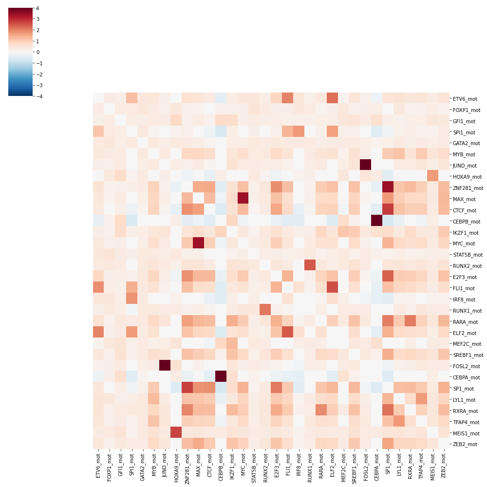

```python
# enrichment for each motifs
fig = sns.clustermap(enr.iloc[63:][enr.columns[63:]],figsize=(14,14), row_cluster=0, col_cluster=0, vmax=4, vmin=-4, cmap='RdBu_r')
fig.savefig('../results/'+project+'/plots/'+version+'_'+merging_version+'_'+window+'_enrichment_ofmotifs_on_motifs.pdf')
plt.show()
```

```python
len(merged[merged['CTCF']!=0]), len(merged[merged['MEF2C_mot']!=0]), len(merged[merged['SP1']!=0]), len(merged[merged['SP1']!=0])
```

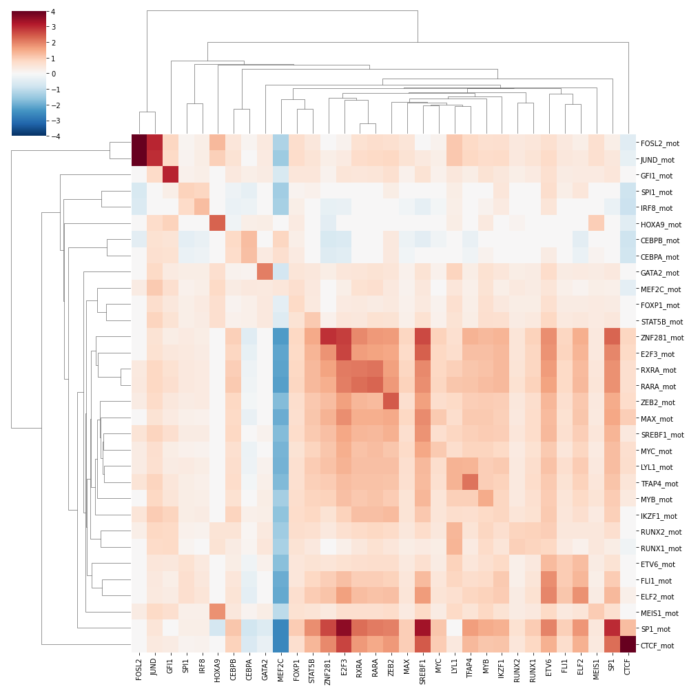

```python
# enrichment for each tf signal on associated motifs
data = enr.loc[enr.columns[63:]][[i.split('_')[0] for i in enr.columns[63:]]]
link = linkage(data, optimal_ordering=True)
fig = sns.clustermap(data, figsize=(14,14), row_linkage=link, col_linkage=link, vmax=4, vmin=-4, cmap='RdBu_r')
fig.savefig('../results/'+project+'/plots/'+version+'_'+merging_version+'_'+window+'_enrichment_crc_tfs_onmotifs.pdf')
plt.show()
```

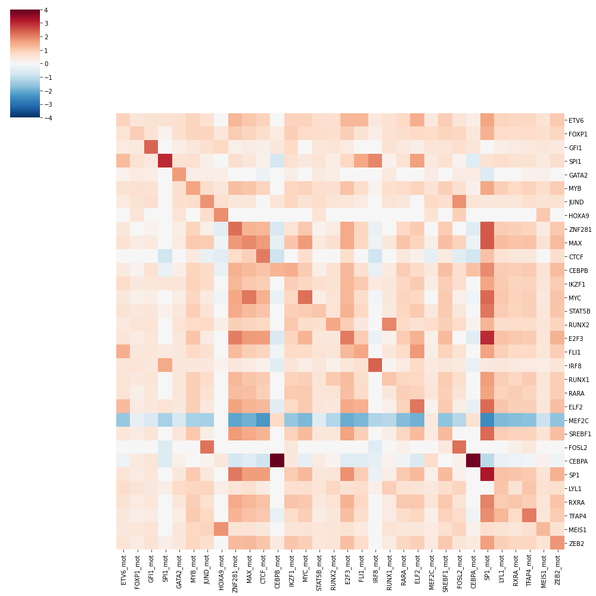

```python
# enrichment for each motifs on associated tf signal
fig = sns.clustermap(enr.loc[[i.split('_')[0] for i in enr.columns[63:]]][enr.columns[63:]], figsize=(14,14), row_cluster=0, col_cluster=0, vmax=4, vmin=-4, cmap='RdBu_r')
fig.savefig('../results/'+project+'/plots/'+version+'_'+merging_version+'_'+window+'_enrichment_ofmotifs_on_crc_tfs.pdf')
plt.show()
```

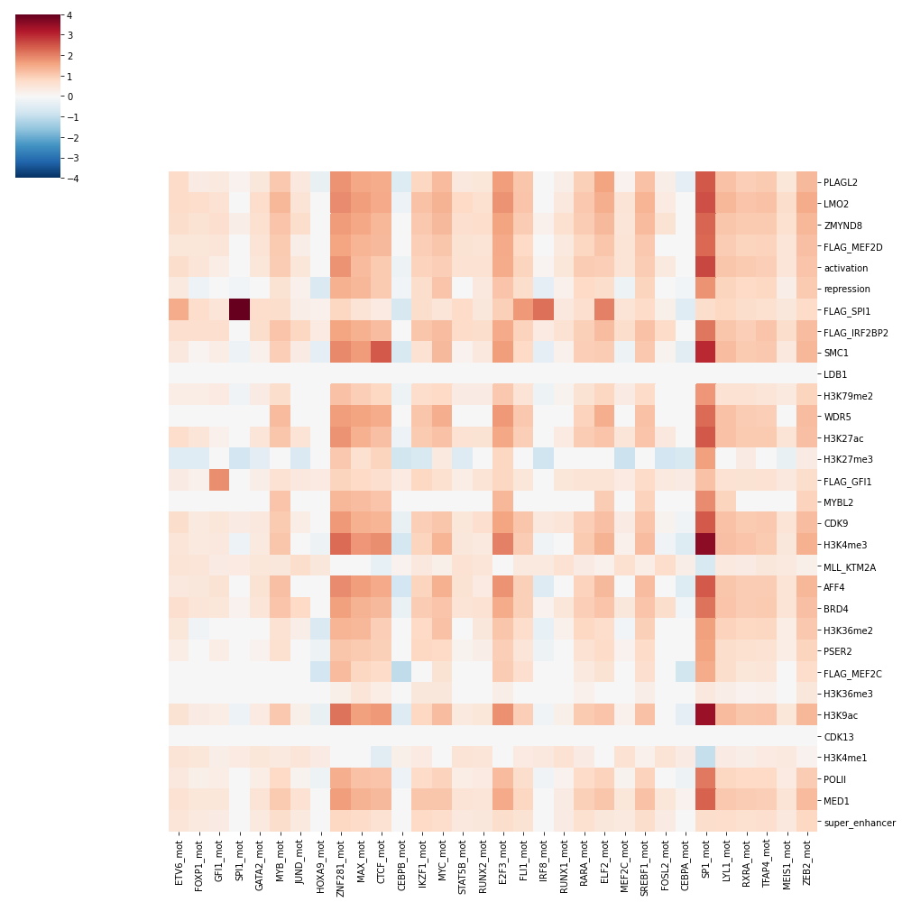

```python
# enrichment on non motif peaks
fig = sns.clustermap(enr.loc[[i for i in enr.columns[:63] if i+'_mot' not in enr.columns[63:]]][enr.columns[63:]],figsize=(14, 14), row_cluster=0, col_cluster=0, vmax=4, vmin=-4, cmap='RdBu_r')
fig.savefig('../results/'+project+'/plots/'+version+'_'+merging_version+'_'+window+'_enrichment_ofmotifs_on_non_motif_tfs.pdf')
plt.show()
```

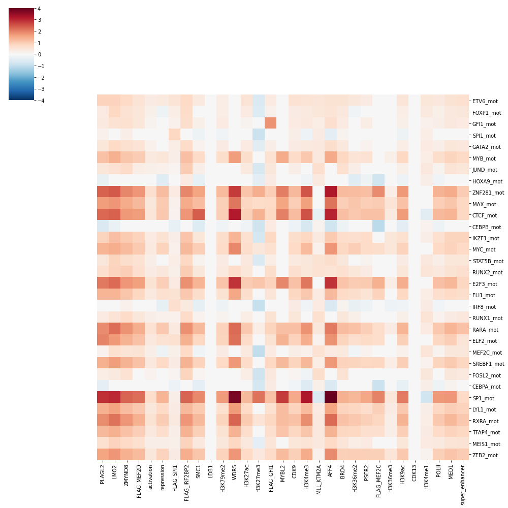

```python
# enrichment on non motif peaks
data = enr.loc[enr.columns[63:]][[i for i in enr.columns[:63] if i+'_mot' not in enr.columns[63:]]]
fig = sns.clustermap(data,figsize=(14, 14), row_cluster=0, col_cluster=0, vmax=4, vmin=-4, cmap='RdBu_r')
fig.savefig('../results/'+project+'/plots/'+version+'_'+merging_version+'_'+window+'_enrichment_of_non_motif_tfs_onmotifs.pdf')
plt.show()
```

### Computing motif enrichment in chip clusters

```python
project="Cobinding_ChIP"
version="v3"
merging_version="remove_single"
window="150"
```

```python
%store -r cols
%store -r annot
```

```python
merged = pd.read_csv('../results/'+project+'/merged_'+version+'_'+merging_version+'_'+window+'_with_annotations.bed.gz', sep='\t')
```

```python
data= merged[merged.columns[cols:annot]].values
scaled_data = (data-data.min(0))/(data.max(0)-data.min(0))
```

```python
n = 3
n_clust=[10,20,50,100,300]
kmean = KMeans(n_clusters=n_clust[n],n_jobs=8)
groups = kmean.fit_predict(scaled_data)
```

```python
enr, pvals = chip.enrichment(merged[merged.columns[:8].tolist() + merged.columns[71:].tolist()], groups=groups)
```

Heatmap showing the enrichment in binding motifs for a specific TF of each clusters. Clusters were computed from clustering the peaks of the cobinding matrix based on the scaled signal of each TF. Enrichment are computed from a fisher exact test on expected overlap compared to observed overlap. pvalues are corrected for mutiple hypothesis testing using the BH method. only enrichment with an adjusted pval<0.001 are reported

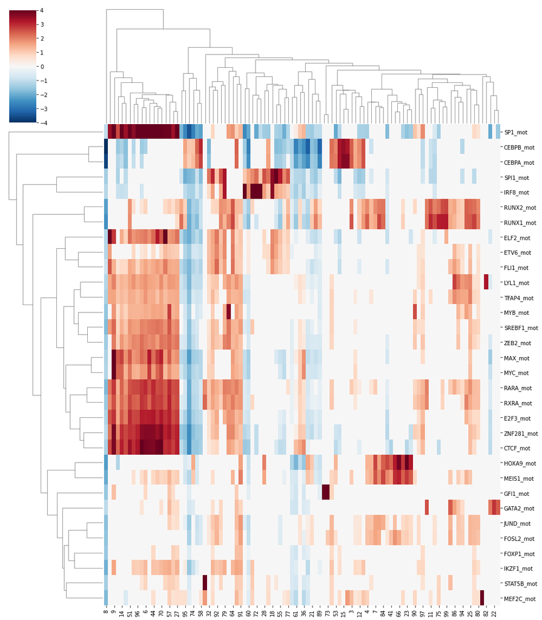

```python
# enrichment for each cluster
fig = sns.clustermap(enr, figsize=(14,16), vmax=4, vmin=-4, cmap='RdBu_r')
fig.savefig('../results/'+project+'/plots/'+version+'_'+merging_version+'_'+window+'_kmeans_'+str(n_clust[n])+'_enrichment_ofmotifs_on_cluster.pdf')
plt.show()
```

## QCing and motif discovering chips with MEME-chip

```python
## computing predicted motif for each TF from Chip data MEME-Chip
## computing motif across the open region of the genome of MV411 from ATACseq with MEME.mast

    ! mkdir ../../data/$project/MEME_$version/
    ! cp ../../data/$project/ATAC_MV411.mRp.clN_peaks.broadPeak ../../data/$project/ATAC_MV411.mRp.clN_peaks.bed && $gatk FastaAlternateReferenceMaker -R ../../data/ref/Homo_sapiens_assembly38.fasta -O ../temp/middle.fasta -L ../../data/$project/ATAC_MV411.mRp.clN_peaks.bed -V ../temp/input_snp.vcf.gz && fold ../temp/middle.fasta -w 500 > ../../data/$project/MEME_$version/$chip.fasta

    cmd = "export PATH=$HOME/meme/bin:$HOME/meme/libexec/meme-5.1.1:$PATH && meme-chip --oc ../../data/"+project+"/MEME_"+version+"/"+chip+"/ -db ../../motif_databases/HUMAN/HOCOMOCOv11_full_HUMAN_mono_meme_format.meme ../../data/"+project+"/MEME_"+version+"/"+chip+".fasta"
    ! $cmd

    ! gff2bed < ../../data/$project/MEME_$version/$chip/fimo.gff > ../../data/$project/MEME_$version/$chip.gff.bed
```

```python
## comparing with the litterature using MEME.tomtom
```

## Assigning genes

### based on closest expressed gene

```python
chiphelper.AssignToClosestExpressed()
```

```python
### recompute cobinding based on this.
```

```python
## redo the plots. do we get better plots?/correlations?...
```

### based on the ABC model

[figure not shown]

They tested a new model based on and validated by CRISPRi-FlowFISH which is basically able to find enhancer mapping to genes. They used it to compute their model's Accuracy and found a 70% accuracy compared to less than 50% for closest expressed gene.

Way to integrate our HiC data (need ATAC-seq like data as well, but openly available)

[figure not shown]

```python
Helper.scatter(TSNE(2,5).fit_transform(data.T), labels=zones.columns[11:],colors=labels)
```

```python
### recompute cobinding based on this.
```

```python
### redo the plots. do we get better looking plots?
```

```python
### compare presence of CTCF and transcription of linked RNA
```

## Predict

```python
## enrichment at the gene set level
```

```python
## are our cobinding clusters enriched in some sets of genes / CRC?
```

```python
## make a linear model to with marks and cobinding data + motifs and TFs+cobinding motifs + expression of cobound proteins + expression , can we predict expression/dependenccy?
```

```python
## can we predict better for some set of genes / CRCs?
```

```python
## do the same on closest expressed gene
```

```python
## do this prediction on each enhancer.what is the best predicting enhancer? do that correlate with ABC model data?
```

```python
## do we get, for some gene, better single enhancer prediction?
```

```python
## what are the gene sets enriched in each clusters?? (based on TF cobinding or based on TF cobinding + )
```

## RNP data

```python
## can we predict RNP data (setting this TF to zero and lookingg at expected RNA change)
## do we see genes with opposite effects?
```

```python
## if we add RNP data, can we increase our model's prediction? (we have expression change and we set all RNPed-TF values to 0)
```

```python
### to predict remaining X% RNA expression
### to predict remaining X TFs RNP
### to predict regular RNA expression
```

```python
## same thing with filtering base on motif presence (actual DNA binding)
## same thing with closest expressed gene
```

```python
## Do on all cell lines
```

```python
## repeat the process across all samples with H3K27ac+RNAseq data we have.
```

```python
## call mutations from H3k27ac data
```

```python
## MEME analysis of likely bound TFs, except if TF is not expressed
```

```python
## compute enrichments
```

```python
## from same gene assignements, as found on the general consensus peak set, can we find good dependency/expression prediction
```

### Compare data with other labs (H3K27, HiC..)

we need to redo everything for similar normal cell type, getting TFs based on the CRC (find it with CRCmapper or on litterature)